# Vinhetas

Fernando Mayer & Walmes Zeviani

61 RBRAS | 23 a 25 de Maio | Salvador/BA

# Por que Fazer Vinhetas?

- *Vignette*: vinheta, esboço, epsódio, jingle …
- A documentação do pacote é longa e individualizada.
- A vinheta é uma visão geral.
- Ilustrar o uso coordenado de funções para um propósito.
- Não tem restrição de tamanho, forma ou quantidade.
- Vinhetas são a melhor forma de divulgar o pacote.
- Permitem tabelas, gráficos, equações e referências bibliográficas.

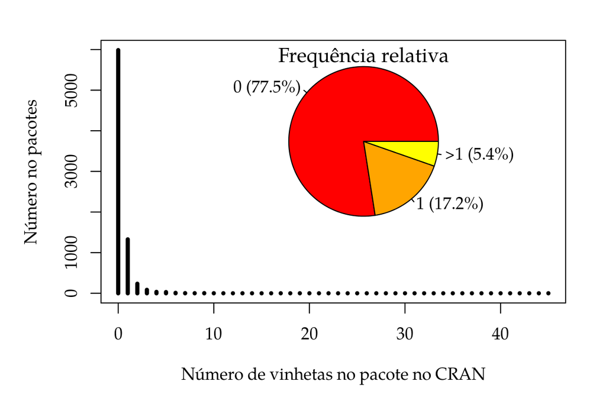

Desde a versão 3.0.0 do R…

- Vinhetas não Sweave são permitidas.
- Rmd - RMarkDown: prosa em MarkDown + código R = {html, pdf}.
- Rnw-knitr - prosa em LaTex + código R = pdf.
- Vinhetas em Rnw-Sweave permanecem válidas.

As vinhetas podem ser…

- Artigos completos em PDF, com texto, equações, tabelas, gráficos e referências.
- Usadas como páginas HTML na web como tutoriais, material de ensino ou matérias de blog.
- Material de Curso contidas em um pacote com dados e funções disponibilizado aos participantes.
- O TCC/Dissertação/Tese e o pacote disponibilizado é o produto final.

# Consultando as Vinhetas Disponíveis

```r
# Abre no navegador.
browseVignettes()

# Exibe no console.
vignette()

# Filtra por pacote.
browseVignettes(package = "devtools")
vignette(package = "devtools")

# Abre a vinheta.
vignette(topic = "dependencies", package = "devtools")
```

# Construindo a Estrutura para Vinhetas

Na raíz do diretório do pacote

```r
library(devtools)

use_vignette(name = "AnaExpDIC")
```

Cria de diretório e arquivos

```
* Creating `vignettes`.
* Adding `inst/doc` to ./.gitignore
```

```
.
`-- vignettes/
    `-- AnaExpDIC.Rmd
```

Acrescenta automaticamente ao `DESCRIPTION`

```
Suggests: knitr,
    rmarkdown
VignetteBuilder: knitr
```

# Vinheta em RMarkDown para documento HTML

Metadados criados por padrão pela `use_vignettes()`

```
---
title: "Vignette Title"
author: "Vignette Author"
date: "`r Sys.Date()`"
output: rmarkdown::html_vignette
vignette: >
  %\VignetteIndexEntry{Vignette Title}
  %\VignetteEngine{knitr::rmarkdown}
  %\VignetteEncoding{UTF-8}
---
```

Também pode ser usado `rmarkdown::html_document`, além de outros.

# Vinheta em RMarkDown para documento PDF

Use `rmarkdown::pdf_document`

```
---
title: "Vignette Title"
author: "Vignette Author"
date: "`r Sys.Date()`"
output: rmarkdown::pdf_document
vignette: >
  %\VignetteIndexEntry{Vignette Title}
  %\VignetteEngine{knitr::rmarkdown}
  %\VignetteEncoding{UTF-8}
---
```

# Vinheta em Rnw-knitr para documento PDF

Crie um documento Rnw com os metadados no topo

```
%\VignetteEngine{knitr::knitr}
%\VignetteIndexEntry{Vignette Title}
%\VignetteEncoding{UTF-8}

\documentclass{article}

... Preambulo ...

\begin{document}

... Corpo do texto ...

\end{document}
```

Use *chunk headers* do knitr.

Estrutura resumida dos tipos de Vinheta

```
Rmd -> HTML | PDF
|-- output:
|   |-- rmarkdown::html_vignette
|   |-- rmarkdown::html_document
|   `-- rmarkdown::pdf_document
|-- vignette: >
|     %\VignetteIndexEntry{Vignette Title}
|     %\VignetteEngine{knitr::rmarkdown}
|     %\VignetteEncoding{UTF-8}
`-- DESCRIPTION
      Suggests: knitr,
          rmarkdown
      VignetteBuilder: knitr

Rnw -> PDF
|-- vignette: >
|     %\VignetteIndexEntry{Vignette Title}
|     %\VignetteEngine{knitr::knitr}
|     %\VignetteEncoding{UTF-8}
`-- DESCRIPTION
      Suggests: knitr,
      VignetteBuilder: knitr
```

# Compilando as Vinhetas

Gera o documento final e move arquivos

```r
# Gera e move todas as vinhetas em vignettes/.
# build_vignettes(dependencies = FALSE)
build_vignettes()
```

```
Building labestData vignettes
Moving AnaExpDIC.pdf, anaExpDBC.pdf, AnaExpDIC.R,
anaExpDBC.R to inst/doc/
Copying AnaExpDIC.Rmd, anaExpDBC.Rnw to inst/doc/
```

Verifica o pacote e o código da vinheta

```r
check()
```

```
... omitido ...
* checking installed files from ‘inst/doc’ ... OK
* checking files in ‘vignettes’ ... OK
* checking examples ... OK
* checking for unstated dependencies in vignettes ... OK
* checking package vignettes in ‘inst/doc’ ... OK
* checking re-building of vignette outputs ... OK
* DONE
```

# Gerando as Vinhetas Individualmente

- Útil quando a vinheta está sendo desenvolvida.
- `build_vignettes()` demora porque compila todas as vinhetas.

```r
rmarkdown::render("vignettes/AnaExpDIC.Rmd")
```

```
./vignettes
|-- AnaExpDIC.html
`-- AnaExpDIC.Rmd
```

Na `vignettes/` ficam os fontes e arquivos auxiliares, na `inst/doc` apenas os *outputs* finais.

# MarkDown vs LaTeX

- Markdown é mais vantajoso.
- Menor distração, foco no conteúdo.
- Tem os ambinentes mais importantes.
- É facilmente convertido para outros formatos de saída.
- Converte bem para LaTeX.
- Aceita código LaTeX e HTML no meio do MarkDown.

Existe bastante recurso no MarkDown-Pandoc.

```
title: Minha Vinheta
author: Joselito
graphics: yes
output:
  pdf_document:
    highlight: default
    template: template.tex
    keep_tex: true
  html_document:
    highlight: default
    css: _style.css
    includes:
      in_header: _MathJax.html
      before_body: _before_body.html
      after_body: _after_body.html
bibliography: refs.bib
csl: ABNT_UFPR_2011-Mendeley.csl
```

Visite http://rmarkdown.rstudio.com/index.html.

# Pacotes para Consulta

- [`MRDCr`](https://github.com/leg/MRDCr/) - *Modelos de Regressão para Dados de Contagem com o R*, Walmes Zeviani, Eduardo Jr e Cesar Taconeli (LEG/UFPR). [`labestData`](https://github.com/pet-estatistica/labestData) - *Conjuntos de Dados para Ensino de Estatística*, PET Estatística UFPR.
- [`mcglm`](https://github.com/wbonat/mcglm/) - *Multivariate Covariance Generalized Linear Models*, Wagner Hugo Bonat e colaboradores (LEG/UFPR).
- [`breedR`](https://github.com/famuvie/breedR/) - *Statistical Methods for Forest Genetic Resources analysts*, Facundo Muñoz.
- [`bbmle`](https://github.com/cran/bbmle/) - *Tools for General Maximum Likelihood Estimation*, Ben Bolker.
- [`knitr`](https://github.com/yihui/knitr) - *Elegant, flexible and fast dynamic report generation with R*, Yihui Xie.

# Considerações Finais

- A documentação é especifica e individualizada, as vinhetas são gerais e coordenadas.
- As vinhetas são a representação mais fiel de Pesquisa Reproduzível com o R.
- Os pacotes `devtools` tem recursos que facilitam a criação e manutenção de vinhetas no pacote.
- O `knitr` junto com o PanDoc facilitam a elaboração de vinhetas em RMarkDown.
- Vinhetas em HTML tem sido utilizadas com frequência pois permitem animações em Gif, videos, JavaScript e Shiny.

# Além disso

- Use um Sistema de Controle de Versão (e.g. Git).
- Disponibilize seu código (e.g. GitHub ou GitLab).
- Disponibilize suas vinhetas no GitHub com `gh-pages`.

# Mais

Classes, Genéricas e Métodos em S3